# Week 2 Exercises

# Exercise 4

#### 4.1

Using ggplot2, create a scatter plot with score1 on the x-axis and score2 on the y-axis.

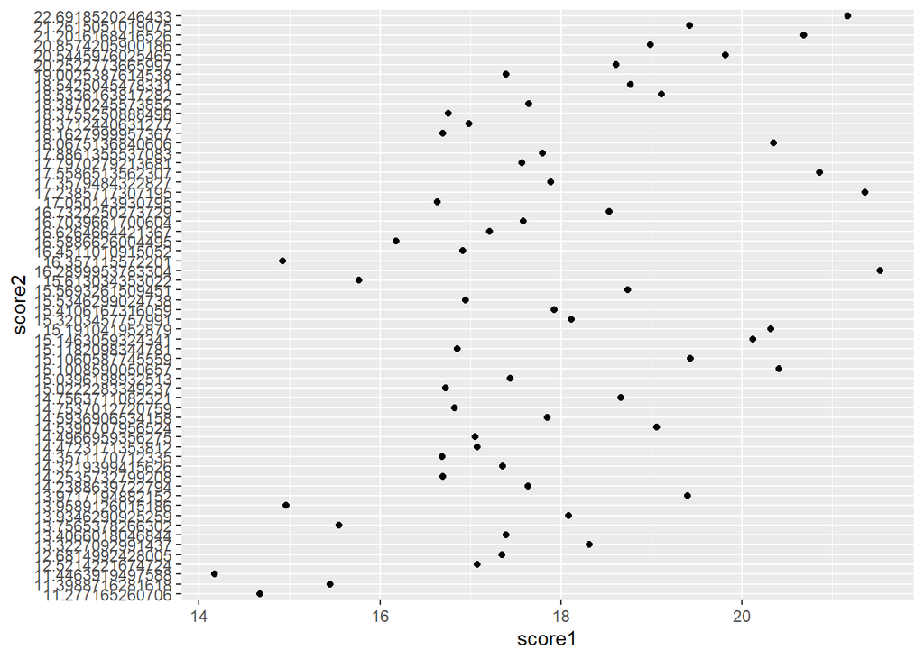

```r
df %>%
  ggplot(aes(x = score1, y = score2)) +
  geom_point()
```

#### 4.2

Continuing with the previous plot, colour the points based on gender.

Set the output figure width to 10 and height to 6.

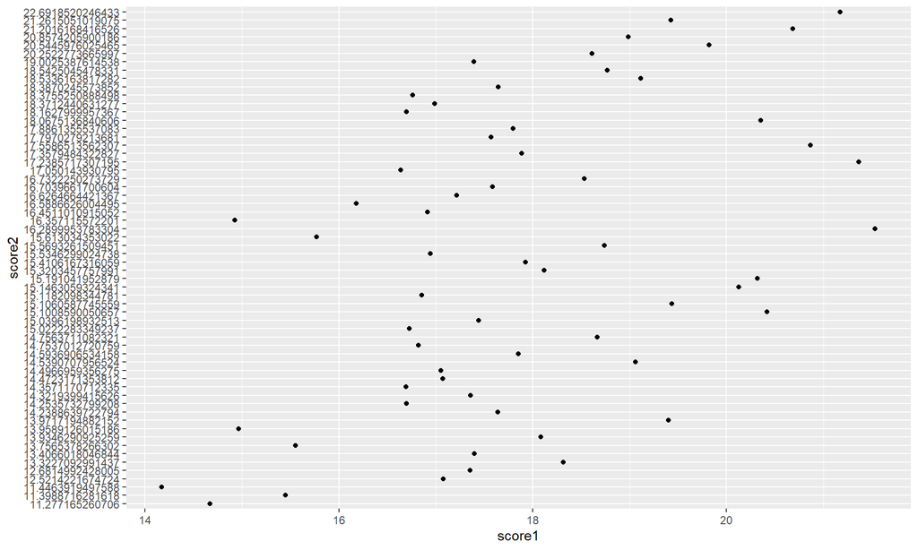

```r
df %>%
  ggplot(aes(x = score1, y = score2)) +
  geom_point()
```

# Exercise 5

#### 5.1

Add the author (your name) and date into the metadata section. Create a table of contents.

#### 5.2

Knit your document to HTML by changing `html_notebook` to `html_document` in the metadata, and pressing Knit.